# prictice 4

```r
library(ggplot2)
summary(diamonds)
```

```
     carat               cut        color
 Min.   :0.2000   Fair     : 1610   D: 6775
 1st Qu.:0.4000   Good     : 4906   E: 9797
 Median :0.7000   Very Good:12082   F: 9542
 Mean   :0.7979   Premium  :13791   G:11292
 3rd Qu.:1.0400   Ideal    :21551   H: 8304
 Max.   :5.0100                     I: 5422
                                    J: 2808
    clarity          depth           table
 SI1    :13065   Min.   :43.00   Min.   :43.00
 VS2    :12258   1st Qu.:61.00   1st Qu.:56.00
 SI2    : 9194   Median :61.80   Median :57.00
 VS1    : 8171   Mean   :61.75   Mean   :57.46
 VVS2   : 5066   3rd Qu.:62.50   3rd Qu.:59.00
 VVS1   : 3655   Max.   :79.00   Max.   :95.00
 (Other): 2531
     price             x                y
 Min.   :  326   Min.   : 0.000   Min.   : 0.000
 1st Qu.:  950   1st Qu.: 4.710   1st Qu.: 4.720
 Median : 2401   Median : 5.700   Median : 5.710
 Mean   : 3933   Mean   : 5.731   Mean   : 5.735
 3rd Qu.: 5324   3rd Qu.: 6.540   3rd Qu.: 6.540
 Max.   :18823   Max.   :10.740   Max.   :58.900

       z
 Min.   : 0.000
 1st Qu.: 2.910
 Median : 3.530
 Mean   : 3.539
 3rd Qu.: 4.040
 Max.   :31.800
```

Your first task is to create a scatterplot of price vs x. using the ggplot syntax.

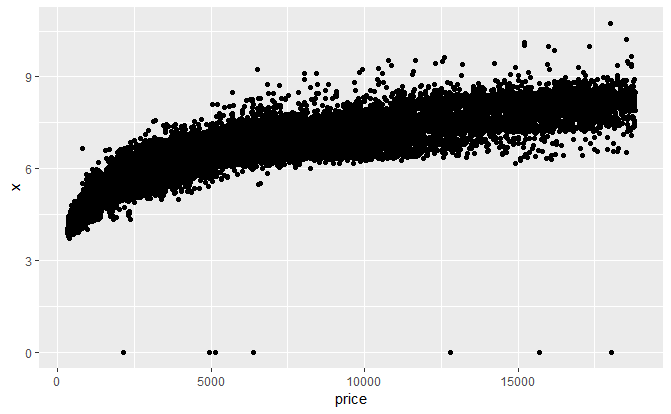

```r
ggplot(data = diamonds, aes(x = price, y = x)) +
  geom_point()
```

```r
cor.test(diamonds$price, diamonds$x)
```

```
    Pearson's product-moment correlation

data:  diamonds$price and diamonds$x
t = 440.16, df = 53938, p-value < 2.2e-16
alternative hypothesis: true correlation is not equal to 0
95 percent confidence interval:
 0.8825835 0.8862594
sample estimates:
      cor
0.8844352
```

```r
cor.test(diamonds$price, diamonds$y)
```

```
    Pearson's product-moment correlation

data:  diamonds$price and diamonds$y
t = 401.14, df = 53938, p-value < 2.2e-16
alternative hypothesis: true correlation is not equal to 0
95 percent confidence interval:
 0.8632867 0.8675241
sample estimates:
      cor
0.8654209
```

```r
cor.test(diamonds$price, diamonds$z)
```

```
    Pearson's product-moment correlation

data:  diamonds$price and diamonds$z
t = 393.6, df = 53938, p-value < 2.2e-16
alternative hypothesis: true correlation is not equal to 0
95 percent confidence interval:
 0.8590541 0.8634131
sample estimates:
      cor
0.8612494
```

Create a simple scatter plot of price vs depth.

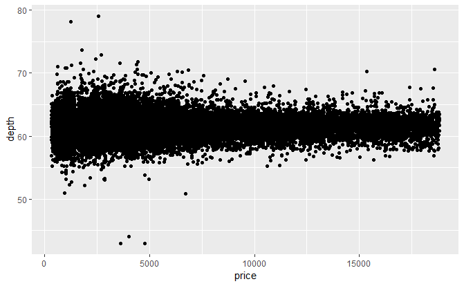

```r
ggplot(data = diamonds, aes(x = price, y = depth)) +
  geom_point()
```

Change the code to make the transparency of the points to be 1/100 of what they are now and mark the x-axis every 2 units. See the instructor notes for two hints. 提示 1：在 geom_point() 中，使用 alpha 参数调整点的透明度。 提示 2：使用带有 breaks 参数的 scale_x_continuous() 调整 x 轴。

```r
range(diamonds$price)
```

```
[1]   326 18823
```

[figure not shown]

```r
ggplot(data = diamonds, aes(x = price, y = depth)) +
  geom_point(alpha = 1/100) +
  scale_x_continuous(breaks = seq(0, 19000,2))
```

```r
cor.test(diamonds$price, diamonds$depth)
```

```
    Pearson's product-moment correlation

data:  diamonds$price and diamonds$depth
t = -2.473, df = 53938, p-value = 0.0134
alternative hypothesis: true correlation is not equal to 0
95 percent confidence interval:
 -0.019084756 -0.002208537
sample estimates:
       cor
-0.0106474
```

Create a scatterplot of price vs carat and omit the top 1% of price and carat values.

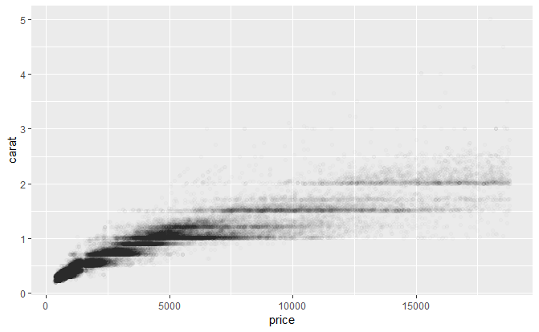

```r
ggplot(data = diamonds, aes(x = price, y = carat)) +
  geom_point(alpha = 1/100)
```

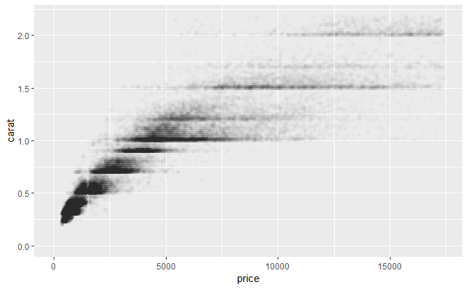

```r
ggplot(data = diamonds, aes(x = price, y = carat)) +
  geom_point(alpha = 1/100) +
  xlim(0, quantile(diamonds$price, 0.99)) +
  ylim(0, quantile(diamonds$carat, 0.99))
```

Create a scatterplot of price vs. volume (x * y * z). This is a very rough approximation for a diamond’s volume.

Create a new variable for volume in the diamonds data frame. This will be useful in a later exercise.

Don’t make any adjustments to the plot just yet.

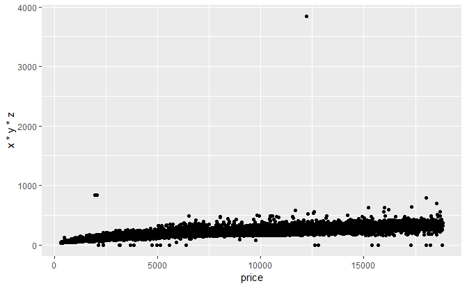

```r
ggplot(data = diamonds, aes(x = price, y = x * y * z)) +
  geom_point()
```

提示 1：向钻石数据框中添加一个体积变量很有帮助。你应该排除体积大于或等于 800 的钻石。而且，还要排除体积为 0 的钻石。当你子集化原始数据框时，在两个条件之间使用 & 符号。

提示 2：在这些条件下子集化钻石数据框，并且将它保存到另一个变量中。在 cor() 函数中使用该数据框。

```r
diamonds$volume <- diamonds$x * diamonds$y * diamonds$z
volume_group <- subset(diamonds, volume < 800 & volume > 0)
cor.test(volume_group$price,volume_group$volume)
```

```
    Pearson's product-moment correlation

data:  volume_group$price and volume_group$volume
t = 559.19, df = 53915, p-value < 2.2e-16
alternative hypothesis: true correlation is not equal to 0
95 percent confidence interval:
 0.9222944 0.9247772
sample estimates:
      cor
0.9235455
```

Adjust the transparency of the points and add a linear model to the plot. (See the Instructor Notes or look up the documentation of geom_smooth() for more details about smoothers.)

We encourage you to think about this next question and to post your thoughts in the discussion section.

Do you think this would be a useful model to estimate the price of diamonds? Why or why not?

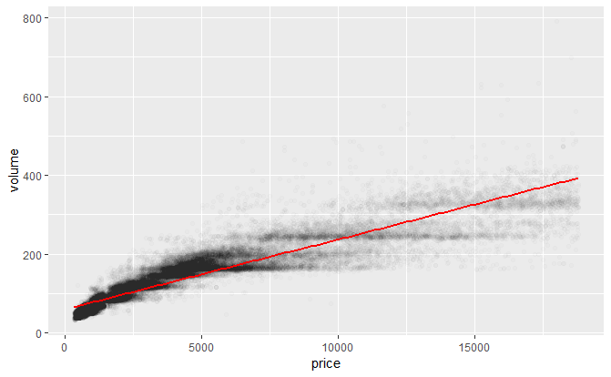

```r
ggplot(aes(x = price, y = volume), data = volume_group ) +
  geom_point(alpha = 1/100) +
  geom_smooth(method = 'lm', color = 'red')
```

Use the function dplyr package to create a new data frame containing info on diamonds by clarity.

Name the data frame diamondsByClarity

The data frame should contain the following variables in this order.

```
  (1) mean_price
  (2) median_price
  (3) min_price
  (4) max_price
  (5) n
```

where n is the number of diamonds in each level of clarity.

```r
suppressMessages(library(dplyr))
diamonds_by_clarity <- group_by(diamonds, clarity)
diamondsByClarity <- summarise(diamonds_by_clarity,
          mean_price = mean(price),
          median_price = median(price),
          min_price = min(price),
          max_price = max(price),
          n = n())
diamondsByClarity <- arrange(diamondsByClarity, clarity)
```

We’ve created summary data frames with the mean price by clarity and color. You can run the code in R to verify what data is in the variables diamonds_mp_by_clarity and diamonds_mp_by_color.

Your task is to write additional code to create two bar plots on one output image using the grid.arrange() function from the package gridExtra.

```r
diamonds_by_clarity <- group_by(diamonds, clarity)
diamonds_mp_by_clarity <- summarise(diamonds_by_clarity, mean_price = mean(price))
diamonds_by_color <- group_by(diamonds, color)
diamonds_mp_by_color <- summarise(diamonds_by_color, mean_price = mean(price))
```

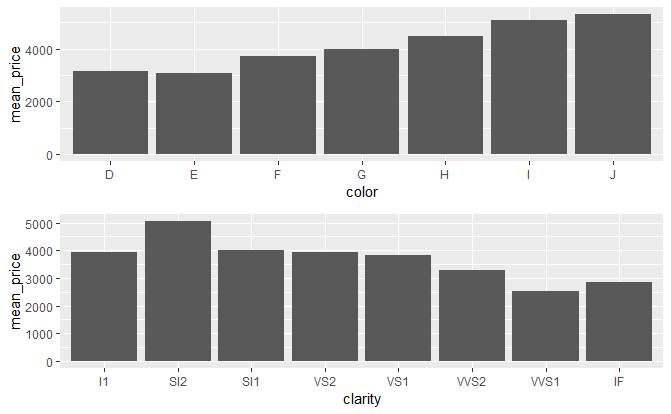

```r
library(gridExtra)
p1 <- ggplot(diamonds_mp_by_clarity,aes(clarity, mean_price)) +
  geom_col()
p2 <- ggplot(diamonds_mp_by_color,aes(color, mean_price)) +
  geom_col()
grid.arrange(p2, p1, ncol = 1)
```

```r
head(diamonds_mp_by_clarity)
```

| clarity | mean_price |
| --- | --- |
| I1 | 3924.169 |
| SI2 | 5063.029 |
| SI1 | 3996.001 |
| VS2 | 3924.989 |
| VS1 | 3839.455 |
| VVS2 | 3283.737 |

```r
head(diamonds_mp_by_color)
```

| color | mean_price |
| --- | --- |
| D | 3169.954 |
| E | 3076.752 |
| F | 3724.886 |
| G | 3999.136 |
| H | 4486.669 |
| I | 5091.875 |